# Analysis for AFRI

Nick Miller

March 16, 2015

# Get the data for differentially expressed genes responding to insecticides

Note that “character” columns get read as factors.

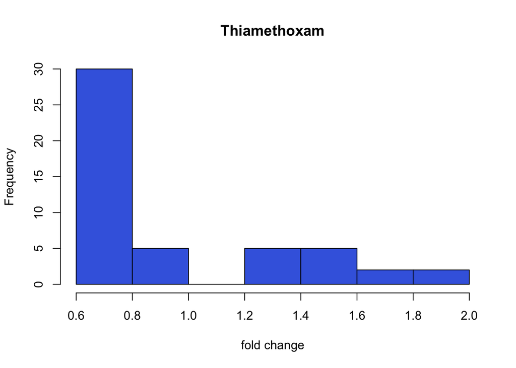

```r
library(xlsx)
thiamethoxam <- read.xlsx("foldchanges.xlsx", 1, colClasses = c("character", "numeric", "character", "character"))
esfenvalerate <- read.xlsx("foldchanges.xlsx", 2, colClasses = c("character", "numeric", "character", "character"))
hist(2^thiamethoxam$log.2.foldchg, main="Thiamethoxam", xlab="fold change", col=colors()[562])
```

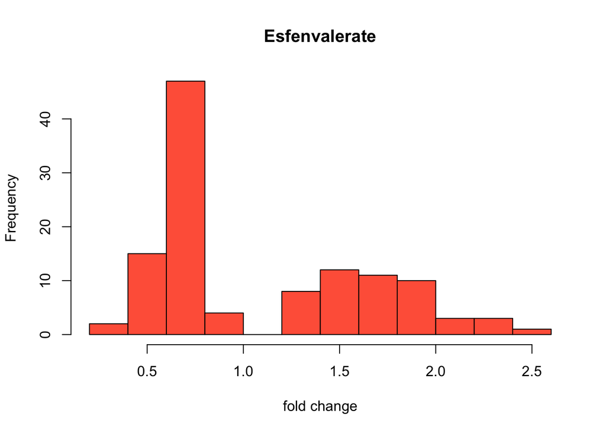

```r
hist(2^esfenvalerate$log.2.foldchg, main="Esfenvalerate", xlab="fold change", col=colors()[630])
```

# Get the correpondences between genes identified by Bansal et al and us

They used a different reference than we did (another argument for having useable genomes). We can see which of their genes correspond to which of ours using blast. 1. Set up a blast db of Sijun’s reference transcriptome. 2. Run sequences of differentially expressed genes from Bansal as queries. 3. Identify hits - not that 1 Bansal seq could legitimately hit >1 of Sijun’s seqs, but we do want to filter out poor hits (short, mismatches)

```r
blast.results <- read.table("blastout")
names(blast.results) <- c("query.id", "subject.id", "pc.identity", "alignment.length", "mismatches", "gap.openings", "q.start", "q.end", "s.start", "s.end", "e-value", "bit.score")
blast.results <- subset(blast.results, alignment.length >= 100)
blast.results <- subset(blast.results, pc.identity >= 98)
```

The fasta file of genes described in the Bansal paper contains 158 contigs, after subsetting blast.results contains 372 entries. Of the 158 Bansal contigs 127 have at least one entry, which isn’t to bad = 80.4 percent.

# Get Rag1 up and downregulated genes from Bansal et al

Read in data from supplementary info file.

```r
rag1.up <- read.xlsx("Bansal_diffreged.xlsx", 1)
rag1.down <- read.xlsx("Bansal_diffreged.xlsx", 2)
```

Now we need to get these converted over to the transcript set we are using. First thing to do is extract only those for which we have a blast-based correspondence.

```r
rag1.up <- subset(rag1.up, as.character(Seq..Name) %in% unique(as.character(blast.results$query.id)))
rag1.down <- subset(rag1.down, as.character(Seq..Name) %in% unique(as.character(blast.results$query.id)))
```

We can use the inner_join from dplyr function to map Bansal’s contig to ours

```r
library(dplyr)

correspondences <- blast.results[,1:2]
names(correspondences) <- c("Seq..Name", "transcript")
transcripts.rag1.up <- as.character((inner_join(correspondences, rag1.up, by="Seq..Name"))$transcript)
transcripts.rag1.down <- as.character((inner_join(correspondences, rag1.down, by="Seq..Name"))$transcript)
```

# Compare expression patterns between esfenvalerate and Rag1

Get the esfenvalerate up/down regulated transcripts

```r
transcripts.esfenvalerate.up <- as.character(subset(esfenvalerate, log.2.foldchg > 0)$transcript)
transcripts.esfenvalerate.down <- as.character(subset(esfenvalerate, log.2.foldchg < 0)$transcript)
```

Upregulated in both

```r
intersect(transcripts.esfenvalerate.up, transcripts.rag1.up)
```

```
## [1] "sba_whole_aphid_contig_6666:"  "sba_whole_aphid_contig_14313:"
## [3] "sba_whole_aphid_contig_5703:"  "sba_whole_aphid_contig_12532:"
## [5] "sba_whole_aphid_contig_15283:"
```

Downregulated in both

```r
intersect(transcripts.esfenvalerate.down, transcripts.rag1.down)
```

```
## character(0)
```

Up in esfenvalerate, down in Rag1

```r
intersect(transcripts.esfenvalerate.up, transcripts.rag1.down)
```

```
## character(0)
```

Down in esfenvalerate, up in Rag1

```r
intersect(transcripts.esfenvalerate.down, transcripts.rag1.up)
```

```
## character(0)
```

So we have a few transcripts that are upregulate in both, what are they?

```r
subset(esfenvalerate, transcript %in% intersect(transcripts.esfenvalerate.up, transcripts.rag1.up))$gene
```

```
## [1] sba_whole_aphid_contig_6666:PREDICTED:cytochrome_P450_18a1-like[Acyrthosiphon_pisum]
## [2] sba_whole_aphid_contig_14313:PREDICTED:probable_cytochrome_P450_6a14-like[Acyrthosiphon_pisum]
## [3] sba_whole_aphid_contig_5703:PREDICTED:cytochrome_P450_4V2-like_isoform1[Acyrthosiphon_pisum]_>gi|328708155|ref|XP_003243610.1|_PREDICTED:cytochrome_P450_4V2-like_isoform_2[Acyrthosiphon_pisum]
## [4] sba_whole_aphid_contig_12532:PREDICTED:cytochrome_P450_4C1-like[Acyrthosiphon_pisum]
## [5] sba_whole_aphid_contig_15283:PREDICTED:cytochrome_P450_6a2-like[Acyrthosiphon_pisum]
## 115 Levels: sba_whole_aphid_contig_10092:cytochrome_P450[Bemisia_tabaci] ...
```

All cytochrome P450s

How many different genes from Bansal’s original reference do we have here?

```r
unique(as.character(subset(correspondences, transcript %in% intersect(transcripts.esfenvalerate.up, transcripts.rag1.up))$Seq..Name))
```

```
## [1] "contig_15324" "contig_16027" "contig_16409" "contig_4861"
## [5] "contig_6786"  "contig_9694"
```

# Compare expression patterns between thiamethoxam and Rag1

Get thiamethoxam up/down regulate transcripts.

```r
transcripts.thiamethoxam.up <- as.character(subset(thiamethoxam, log.2.foldchg > 0)$transcript)
transcripts.thiamethoxam.down <- as.character(subset(thiamethoxam, log.2.foldchg < 0)$transcript)
```

Upregulated in both

```r
intersect(transcripts.thiamethoxam.up, transcripts.rag1.up)
```

```
## [1] "sba_whole_aphid_contig_6666:"
```

Note that this is also a shared upregulated transcript between esfenvalerate and Rag1.

Downregulated in both

```r
intersect(transcripts.thiamethoxam.down, transcripts.rag1.down)
```

```
## [1] "sba_whole_aphid_contig_1839:"
```

What is this?

```r
subset(thiamethoxam, transcript %in% intersect(transcripts.thiamethoxam.down, transcripts.rag1.down))$gene
```

```
## [1] sba_whole_aphid_contig_1839:PREDICTED:esterase_FE4-like[Acyrthosiphon_pisum]
## 48 Levels: sba_whole_aphid_contig_10231:PREDICTED:fumarylacetoacetate_hydrolase_domain-containing_protein_2-like[Acyrthosiphon_pisum] ...
```

An esterase. Note that overporduction of these often implicated in OP resistance.

Up in thiamethoxam down in Rag1

```r
intersect(transcripts.thiamethoxam.up, transcripts.rag1.down)
```

```
## character(0)
```

Down in thiamethoxam, up in Rag1

```r
intersect(transcripts.thiamethoxam.down, transcripts.rag1.up)
```

```
## character(0)
```

# For completeness, compare esfenvalerate and thiamethoxam

Both up

```r
intersect(transcripts.esfenvalerate.up, transcripts.thiamethoxam.up)
```

```
##  [1] "sba_whole_aphid_contig_6666:"  "sba_whole_aphid_contig_4531:"
##  [3] "sba_whole_aphid_contig_4993:"  "sba_whole_aphid_contig_11126:"
##  [5] "sba_whole_aphid_contig_10996:" "sba_whole_aphid_contig_15004:"
##  [7] "sba_whole_aphid_contig_2821:"  "sba_whole_aphid_contig_5532:"
##  [9] "sba_whole_aphid_contig_11204:" "sba_whole_aphid_contig_7898:"
## [11] "sba_whole_aphid_contig_10858:" "sba_whole_aphid_contig_9997:"
## [13] "sba_whole_aphid_contig_7780:"  "sba_whole_aphid_contig_5586:"
```

```r
subset(esfenvalerate, transcript %in% intersect(transcripts.esfenvalerate.up, transcripts.thiamethoxam.up))$gene
```

```
##  [1] sba_whole_aphid_contig_6666:PREDICTED:cytochrome_P450_18a1-like[Acyrthosiphon_pisum]
##  [2] sba_whole_aphid_contig_4531:PREDICTED:probable_cytochrome_P450_6a13-like[Acyrthosiphon_pisum]
##  [3] sba_whole_aphid_contig_4993:PREDICTED:high_affinity_cAMP-specific_and_IBMX-insensitive_3',5'-cyclic_phosphodiesterase_8A-like,partial[Acyrthosiphon_pisum]
##  [4] sba_whole_aphid_contig_11126:PREDICTED:venom_carboxylesterase-6-like[Acyrthosiphon_pisum]
##  [5] sba_whole_aphid_contig_10996:PREDICTED:cAMP-specific_3',5'-cyclic_phosphodiesterase-like[Acyrthosiphon_pisum]
##  [6] sba_whole_aphid_contig_15004:esterase_ybfF-like[Acyrthosiphon_pisum]_>gi|239790074|dbj|BAH71622.1|_ACYPI004279[Acyrthosiphon_pisum]
##  [7] sba_whole_aphid_contig_2821:PREDICTED:sphingomyelin_phosphodiesterase-like_isoform_3[Acyrthosiphon_pisum]
##  [8] sba_whole_aphid_contig_5532:PREDICTED:cGMP-specific_3',5'-cyclic_phosphodiesterase-like_isoform_2[Acyrthosiphon_pisum]_>gi|328720845|ref|XP_001945926.2|_PREDICTED:cGMP-specific_3',5'-cyclic_phosphodiesterase-like_isoform1[Acyrthosiphon_pisum]
##  [9] sba_whole_aphid_contig_11204:acetylcholinesterase[Aphis_gossypii]_>gi|52313434|dbj|BAD51411.1|_acetylcholinesterase[Aphis_gossypii]_>gi|52313436|dbj|BAD51412.1|_acetylcholinesterase[Aphis_gossypii]
## [10] sba_whole_aphid_contig_7898:PREDICTED:abhydrolase_domain-containing_protein_2-like[Acyrthosiphon_pisum]
## [11] sba_whole_aphid_contig_10858:PREDICTED:ubiquitin_carboxyl-terminal_hydrolase_1-like[Acyrthosiphon_pisum]
## [12] sba_whole_aphid_contig_9997:PREDICTED:ubiquitin_carboxyl-terminal_hydrolase_2-like[Acyrthosiphon_pisum]
## [13] sba_whole_aphid_contig_7780:PREDICTED:ubiquitin_carboxyl-terminal_hydrolase_46-like[Acyrthosiphon_pisum]
## [14] sba_whole_aphid_contig_5586:PREDICTED:ubiquitin_carboxyl-terminal_hydrolase_3-like[Acyrthosiphon_pisum]
## 115 Levels: sba_whole_aphid_contig_10092:cytochrome_P450[Bemisia_tabaci] ...
```

Both down

```r
intersect(transcripts.esfenvalerate.down, transcripts.thiamethoxam.down)
```

```
##  [1] "sba_whole_aphid_contig_1380:"  "sba_whole_aphid_contig_7070:"
##  [3] "sba_whole_aphid_contig_3488:"  "sba_whole_aphid_contig_13246:"
##  [5] "sba_whole_aphid_contig_12455:" "sba_whole_aphid_contig_13671:"
##  [7] "sba_whole_aphid_contig_12749:" "sba_whole_aphid_contig_14746:"
##  [9] "sba_whole_aphid_contig_2990:"  "sba_whole_aphid_contig_3277:"
## [11] "sba_whole_aphid_contig_436:"   "sba_whole_aphid_contig_5657:"
## [13] "sba_whole_aphid_contig_11825:" "sba_whole_aphid_contig_13304:"
## [15] "sba_whole_aphid_contig_10390:" "sba_whole_aphid_contig_13827:"
## [17] "sba_whole_aphid_contig_11390:" "sba_whole_aphid_contig_6912:"
## [19] "sba_whole_aphid_contig_9541:"  "sba_whole_aphid_contig_7015:"
## [21] "sba_whole_aphid_contig_8362:"  "sba_whole_aphid_contig_2632:"
## [23] "sba_whole_aphid_contig_6657:"  "sba_whole_aphid_contig_12918:"
## [25] "sba_whole_aphid_contig_15151:" "sba_whole_aphid_contig_1802:"
## [27] "sba_whole_aphid_contig_8446:"  "sba_whole_aphid_contig_10612:"
## [29] "sba_whole_aphid_contig_9343:"  "sba_whole_aphid_contig_10231:"
## [31] "sba_whole_aphid_contig_440:"   "sba_whole_aphid_contig_9011:"
```

```r
subset(esfenvalerate, transcript %in% intersect(transcripts.esfenvalerate.down, transcripts.thiamethoxam.down))$gene
```

```
##  [1] sba_whole_aphid_contig_1380:PREDICTED:cytochrome_P450_4C1-like[Acyrthosiphon_pisum]
##  [2] sba_whole_aphid_contig_7070:glutathione_S-transferase-like_protein[Toxoptera_citricida]
##  [3] sba_whole_aphid_contig_3488:ubiquitin_thioesterase_OTU1[Acyrthosiphon_pisum]_>gi|239791291|dbj|BAH72133.1|_ACYPI008281[Acyrthosiphon_pisum]
##  [4] sba_whole_aphid_contig_13246:esterase_D/formylglutathione_hydrolase-like[Acyrthosiphon_pisum]_>gi|239799401|dbj|BAH70623.1|_ACYPI002273[Acyrthosiphon_pisum]
##  [5] sba_whole_aphid_contig_12455:PREDICTED:esterase_FE4-like[Acyrthosiphon_pisum]
##  [6] sba_whole_aphid_contig_13671:PREDICTED:protein_phosphatase_methylesterase_1-like[Acyrthosiphon_pisum]
##  [7] sba_whole_aphid_contig_12749:PREDICTED:acyl-coenzyme_A_thioesterase_13-like[Acyrthosiphon_pisum]
##  [8] sba_whole_aphid_contig_14746:PREDICTED:esterase_FE4-like[Acyrthosiphon_pisum]
##  [9] sba_whole_aphid_contig_2990:calcineurin-like_phosphoesterase_domain_containing_1[Acyrthosiphon_pisum]_>gi|239792610|dbj|BAH72629.1|_ACYPI008642[Acyrthosiphon_pisum]
## [10] sba_whole_aphid_contig_3277:PREDICTED:esterase_FE4-like[Acyrthosiphon_pisum]
## [11] sba_whole_aphid_contig_436:PREDICTED:probable_tyrosyl-DNA_phosphodiesterase-like_isoform1[Acyrthosiphon_pisum]
## [12] sba_whole_aphid_contig_5657:PREDICTED:trifunctional_nucleotide_phosphoesterase_protein_YfkN-like_isoform_2[Acyrthosiphon_pisum]
## [13] sba_whole_aphid_contig_11825:PREDICTED:palmitoyl-protein_thioesterase_1-like[Acyrthosiphon_pisum]
## [14] sba_whole_aphid_contig_13304:PREDICTED:ubiquitin_carboxyl-terminal_hydrolase_14-like_isoform_2[Acyrthosiphon_pisum]
## [15] sba_whole_aphid_contig_10390:PREDICTED:ubiquitin_carboxyl-terminal_hydrolase_16-like_isoform_2[Acyrthosiphon_pisum]
```

[output cut: 19 more lines]

Up in esfenvalerate, down in thiamethoxam

```r
intersect(transcripts.esfenvalerate.up, transcripts.thiamethoxam.down)
```

```
## character(0)
```

Down in esfenvalerate, up in thiamethoxam

```r
intersect(transcripts.esfenvalerate.down, transcripts.thiamethoxam.up)
```

```
## character(0)
```